# DSP4SH v6 - Indicator Analysis

It’s also helpful to plot the overall effect size for each indicator:

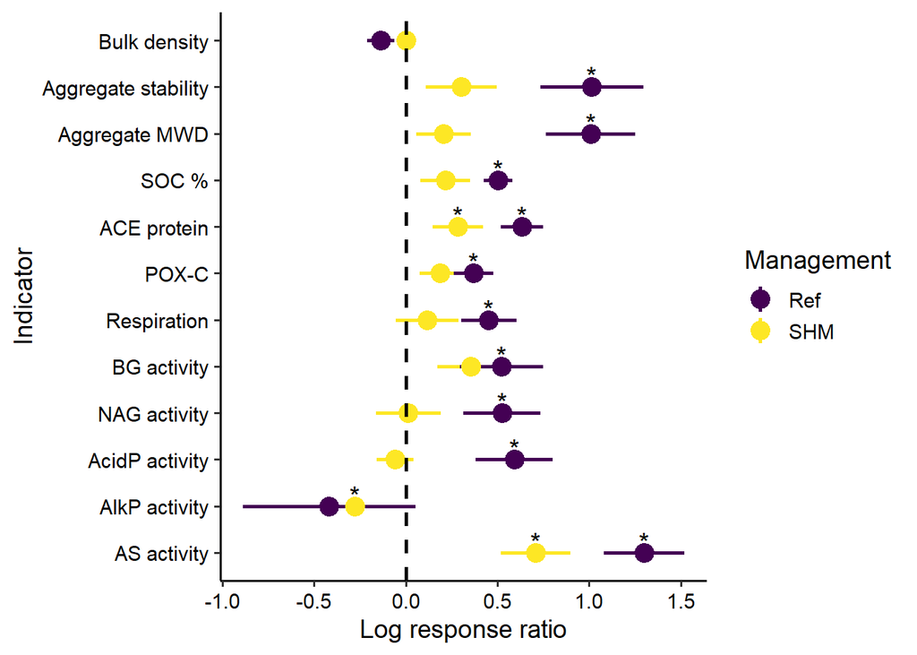

Make table with n for interpretability:

| indicator | label | n |
| --- | --- | --- |
| bulk_density | Ref | 11 |
| bulk_density | SHM | 12 |
| kssl_wsa | Ref | 7 |
| kssl_wsa | SHM | 7 |
| yoder_agg_stab_mwd | Ref | 11 |
| yoder_agg_stab_mwd | SHM | 13 |
| soc_pct | Ref | 9 |
| soc_pct | SHM | 10 |
| ace | Ref | 9 |
| ace | SHM | 10 |
| pox_c | Ref | 11 |
| pox_c | SHM | 13 |
| soil_respiration | Ref | 9 |
| soil_respiration | SHM | 9 |
| bglucosidase | Ref | 11 |
| bglucosidase | SHM | 13 |
| bglucosaminidase | Ref | 10 |
| bglucosaminidase | SHM | 13 |
| acid_phosphatase | Ref | 9 |
| acid_phosphatase | SHM | 11 |
| alkaline_phosphatase | Ref | 10 |
| alkaline_phosphatase | SHM | 13 |
| arylsulfatase | Ref | 10 |
| arylsulfatase | SHM | 12 |

- Biggest difference in results from combining similar treatments is that effect sizes for aggregate stability, SOC%, POX-C, and BG activity in SHM treatment are no longer significantly > 0
- Indicators with the biggest effect sizes in the Ref state (arylsulfatase and both aggregate stabilities) are much lower in the SHM state. Aggregate stability (both methods) is not significantly higher in SHM vs BAU.
- ACE and AS are only two indicators with effect sizes significantly >0 in SHM

| indicator | label | estimate | std.error | statistic | p.value | tau2 | i2 | h2 | q_stat | q_pval | k | q_sig |
| --- | --- | --- | --- | --- | --- | --- | --- | --- | --- | --- | --- | --- |
| bulk_density | Ref | -0.137 | 0.074 | -1.85 | 0.064 | 0.052 | 94.45 | 18.01 | 196.4 | 0.000 | 11 | significant |
| bulk_density | SHM | 0.001 | 0.022 | 0.07 | 0.946 | 0.002 | 50.26 | 2.01 | 20.2 | 0.042 | 12 | significant |
| kssl_wsa | Ref | 1.015 | 0.280 | 3.63 | 0.000 | 0.492 | 91.70 | 12.05 | 85.2 | 0.000 | 7 | significant |
| kssl_wsa | SHM | 0.303 | 0.195 | 1.56 | 0.119 | 0.210 | 80.77 | 5.20 | 32.9 | 0.000 | 7 | significant |
| yoder_agg_stab_mwd | Ref | 1.009 | 0.244 | 4.13 | 0.000 | 0.532 | 95.52 | 22.32 | 220.5 | 0.000 | 11 | significant |
| yoder_agg_stab_mwd | SHM | 0.206 | 0.150 | 1.37 | 0.170 | 0.217 | 96.57 | 29.19 | 69.1 | 0.000 | 13 | significant |
| soc_pct | Ref | 0.503 | 0.079 | 6.38 | 0.000 | 0.039 | 88.34 | 8.57 | 49.9 | 0.000 | 9 | significant |
| soc_pct | SHM | 0.217 | 0.136 | 1.59 | 0.112 | 0.174 | 95.61 | 22.75 | 133.2 | 0.000 | 10 | significant |
| ace | Ref | 0.634 | 0.114 | 5.54 | 0.000 | 0.092 | 89.63 | 9.65 | 68.1 | 0.000 | 9 | significant |
| ace | SHM | 0.284 | 0.136 | 2.09 | 0.037 | 0.164 | 94.57 | 18.41 | 68.3 | 0.000 | 10 | significant |
| pox_c | Ref | 0.370 | 0.107 | 3.46 | 0.001 | 0.116 | 99.99 | 8,743.38 | 510.0 | 0.000 | 11 | significant |
| pox_c | SHM | 0.187 | 0.109 | 1.71 | 0.087 | 0.143 | 98.29 | 58.56 | 144.8 | 0.000 | 13 | significant |
| soil_respiration | Ref | 0.453 | 0.150 | 3.02 | 0.002 | 0.167 | 93.14 | 14.59 | 179.5 | 0.000 | 9 | significant |
| soil_respiration | SHM | 0.117 | 0.170 | 0.69 | 0.490 | 0.226 | 92.00 | 12.50 | 72.2 | 0.000 | 9 | significant |
| bglucosidase | Ref | 0.522 | 0.228 | 2.29 | 0.022 | 0.515 | 95.66 | 23.04 | 178.6 | 0.000 | 11 | significant |
| bglucosidase | SHM | 0.355 | 0.184 | 1.93 | 0.053 | 0.380 | 93.50 | 15.39 | 95.6 | 0.000 | 13 | significant |
| bglucosaminidase | Ref | 0.524 | 0.209 | 2.51 | 0.012 | 0.381 | 95.92 | 24.51 | 98.0 | 0.000 | 10 | significant |
| bglucosaminidase | SHM | 0.013 | 0.177 | 0.07 | 0.942 | 0.349 | 93.96 | 16.55 | 140.7 | 0.000 | 13 | significant |
| acid_phosphatase | Ref | 0.592 | 0.211 | 2.81 | 0.005 | 0.314 | 89.15 | 9.21 | 57.1 | 0.000 | 9 | significant |
| acid_phosphatase | SHM | -0.058 | 0.100 | -0.58 | 0.562 | 0.055 | 66.26 | 2.96 | 34.4 | 0.000 | 11 | significant |
| alkaline_phosphatase | Ref | -0.419 | 0.471 | -0.89 | 0.374 | 1.918 | 98.44 | 63.95 | 69.1 | 0.000 | 10 | significant |
| alkaline_phosphatase | SHM | -0.277 | 0.105 | -2.63 | 0.008 | 0.071 | 68.00 | 3.13 | 45.8 | 0.000 | 13 | significant |
| arylsulfatase | Ref | 1.300 | 0.220 | 5.91 | 0.000 | 0.365 | 91.30 | 11.49 | 71.0 | 0.000 | 10 | significant |
| arylsulfatase | SHM | 0.707 | 0.189 | 3.74 | 0.000 | 0.323 | 87.23 | 7.83 | 85.3 | 0.000 | 12 | significant |

## Calculate random-effects models with moderating variables

Our previous random-effects models only determined if indicators were significantly influenced by treatment. However, those models didn’t include any moderating variables and couldn’t tell us what variables influenced the response of indicators to treatment. Some potential moderating variables of interest are MAT, MAP, land use, and tillage.

### MAT as a moderator variable

Calculate random-effects model with MAT as a moderator variable, generate table of results, and generate table of indicators for which MAT is a significant moderator variable:

| indicator | estimate | std.error | statistic | p.value | tau2 | i2 | h2 | r2 | q_stat | q_pval | q_mod | q_mod_pval | q_sig | q_mod_sig |
| --- | --- | --- | --- | --- | --- | --- | --- | --- | --- | --- | --- | --- | --- | --- |
| bulk_density | 0.011 | 0.011 | 0.97 | 0.331 | 0.029 | 92.95 | 14.17 | 0.57 | 228.0 | 0 | 0.9 | 0.33 | significant | not significant |
| kssl_wsa | 0.012 | 0.049 | 0.24 | 0.811 | 0.497 | 91.61 | 11.93 | 0.00 | 167.7 | 0 | 0.1 | 0.81 | significant | not significant |
| yoder_agg_stab_mwd | 0.007 | 0.045 | 0.16 | 0.874 | 0.543 | 97.90 | 47.57 | 0.00 | 299.1 | 0 | 0.0 | 0.87 | significant | not significant |
| soc_pct | 0.048 | 0.022 | 2.18 | 0.029 | 0.105 | 94.37 | 17.77 | 17.09 | 343.4 | 0 | 4.8 | 0.03 | significant | significant |
| ace | 0.047 | 0.025 | 1.88 | 0.060 | 0.142 | 93.44 | 15.25 | 10.06 | 300.4 | 0 | 3.5 | 0.06 | significant | not significant |
| pox_c | -0.004 | 0.022 | -0.18 | 0.860 | 0.142 | 99.98 | 5,271.15 | 0.00 | 664.8 | 0 | 0.0 | 0.86 | significant | not significant |
| soil_respiration | -0.015 | 0.029 | -0.50 | 0.614 | 0.222 | 93.72 | 15.93 | 0.00 | 260.3 | 0 | 0.3 | 0.61 | significant | not significant |
| bglucosidase | 0.073 | 0.037 | 1.95 | 0.051 | 0.381 | 94.61 | 18.57 | 12.25 | 264.0 | 0 | 3.8 | 0.05 | significant | not significant |
| bglucosaminidase | 0.049 | 0.053 | 0.93 | 0.352 | 0.426 | 95.68 | 23.15 | 0.00 | 433.9 | 0 | 0.9 | 0.35 | significant | not significant |
| acid_phosphatase | -0.019 | 0.055 | -0.34 | 0.735 | 0.284 | 91.57 | 11.86 | 0.00 | 219.1 | 0 | 0.1 | 0.73 | significant | not significant |
| alkaline_phosphatase | 0.033 | 0.081 | 0.40 | 0.687 | 1.021 | 96.93 | 32.59 | 0.00 | 130.9 | 0 | 0.2 | 0.69 | significant | not significant |
| arylsulfatase | 0.114 | 0.051 | 2.21 | 0.027 | 0.373 | 91.56 | 11.85 | 13.70 | 368.0 | 0 | 4.9 | 0.03 | significant | significant |

| indicator | estimate | std.error | statistic | p.value | tau2 | i2 | h2 | r2 | q_stat | q_pval | q_mod | q_mod_pval | q_sig | q_mod_sig |
| --- | --- | --- | --- | --- | --- | --- | --- | --- | --- | --- | --- | --- | --- | --- |
| soc_pct | 0.048 | 0.022 | 2.18 | 0.029 | 0.105 | 94.37 | 17.77 | 17.09 | 343.4 | 0 | 4.8 | 0.03 | significant | significant |
| arylsulfatase | 0.114 | 0.051 | 2.21 | 0.027 | 0.373 | 91.56 | 11.85 | 13.70 | 368.0 | 0 | 4.9 | 0.03 | significant | significant |

Plot relationship between MAT and indicator variables for which it is a significant predictor:

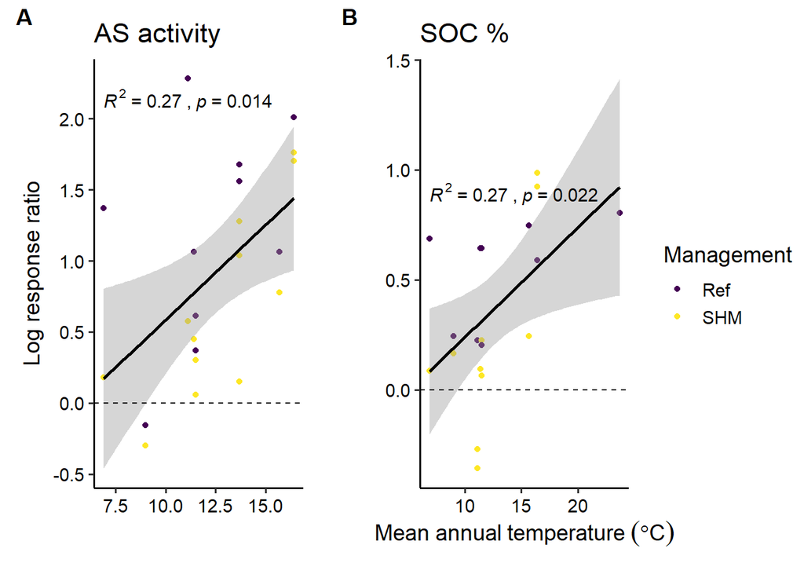

Takeaways:

- MAT is positively correlated with log response ratio for AS activity and SOC%

### MAP as a moderator variable

Calculate random-effects model with MAP as a moderator variable, generate table of results, and generate table of indicators for which MAP is a significant moderator variable:

| indicator | estimate | std.error | statistic | p.value | tau2 | i2 | h2 | r2 | q_stat | q_pval | q_mod | q_mod_pval | q_sig | q_mod_sig |
| --- | --- | --- | --- | --- | --- | --- | --- | --- | --- | --- | --- | --- | --- | --- |
| bulk_density | 0.000 | 0.000 | -1.37 | 0.171 | 0.028 | 91.66 | 12.00 | 4.02 | 246.3 | 0 | 1.9 | 0.17 | significant | not significant |
| kssl_wsa | 0.000 | 0.001 | 0.18 | 0.854 | 0.501 | 91.34 | 11.55 | 0.00 | 166.7 | 0 | 0.0 | 0.85 | significant | not significant |
| yoder_agg_stab_mwd | 0.000 | 0.001 | -0.37 | 0.708 | 0.543 | 97.95 | 48.81 | 0.00 | 295.1 | 0 | 0.1 | 0.71 | significant | not significant |
| soc_pct | 0.000 | 0.000 | -0.40 | 0.692 | 0.133 | 95.93 | 24.57 | 0.00 | 349.0 | 0 | 0.2 | 0.69 | significant | not significant |
| ace | 0.000 | 0.000 | 0.17 | 0.868 | 0.168 | 94.75 | 19.04 | 0.00 | 286.8 | 0 | 0.0 | 0.87 | significant | not significant |
| pox_c | 0.000 | 0.000 | -1.57 | 0.117 | 0.128 | 99.98 | 4,731.25 | 5.15 | 655.0 | 0 | 2.5 | 0.12 | significant | not significant |
| soil_respiration | 0.001 | 0.000 | 1.80 | 0.072 | 0.189 | 93.16 | 14.62 | 10.21 | 272.5 | 0 | 3.2 | 0.07 | significant | not significant |
| bglucosidase | 0.000 | 0.000 | -1.04 | 0.297 | 0.425 | 95.50 | 22.22 | 2.11 | 263.5 | 0 | 1.1 | 0.30 | significant | not significant |
| bglucosaminidase | 0.000 | 0.000 | 0.51 | 0.613 | 0.440 | 95.96 | 24.73 | 0.00 | 437.5 | 0 | 0.3 | 0.61 | significant | not significant |
| acid_phosphatase | 0.000 | 0.000 | -0.76 | 0.449 | 0.273 | 92.11 | 12.68 | 0.00 | 237.4 | 0 | 0.6 | 0.45 | significant | not significant |
| alkaline_phosphatase | -0.002 | 0.001 | -2.47 | 0.013 | 0.849 | 96.41 | 27.85 | 1.67 | 130.3 | 0 | 6.1 | 0.01 | significant | significant |
| arylsulfatase | -0.001 | 0.000 | -2.00 | 0.046 | 0.360 | 91.86 | 12.28 | 16.78 | 324.8 | 0 | 4.0 | 0.05 | significant | significant |

| indicator | estimate | std.error | statistic | p.value | tau2 | i2 | h2 | r2 | q_stat | q_pval | q_mod | q_mod_pval | q_sig | q_mod_sig |
| --- | --- | --- | --- | --- | --- | --- | --- | --- | --- | --- | --- | --- | --- | --- |
| alkaline_phosphatase | -0.002 | 0.001 | -2.47 | 0.013 | 0.849 | 96.41 | 27.85 | 1.67 | 130.3 | 0 | 6.1 | 0.01 | significant | significant |
| arylsulfatase | -0.001 | 0.000 | -2.00 | 0.046 | 0.360 | 91.86 | 12.28 | 16.78 | 324.8 | 0 | 4.0 | 0.05 | significant | significant |

Plot relationship between MAP and indicator variables for which it is a significant predictor:

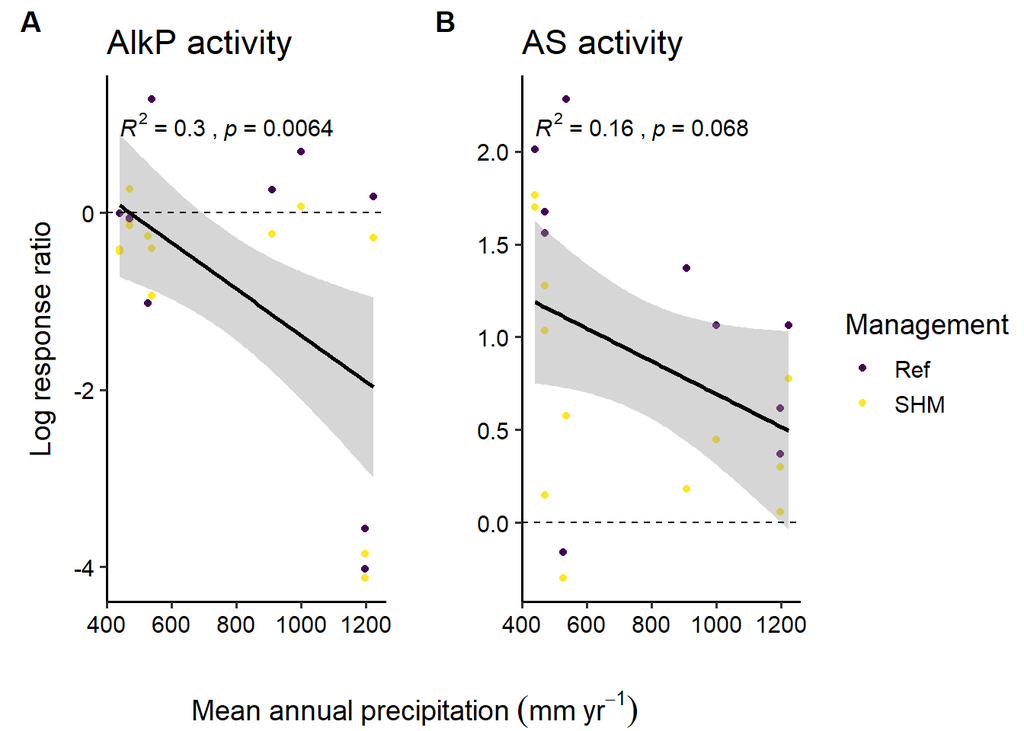

Takeaways:

- MAP is negatively correlated with effect sizes for alkaline phosphatase and arylsulfatase activities

### Land use as a moderator variable

Calculate random-effects model with land use as a moderator variable, generate table of results, and generate table of indicators for which land use is a significant moderator variable:

| indicator | term | estimate | std.error | statistic | p.value | tau2 | i2 | h2 | r2 | q_stat | q_pval | q_mod | q_mod_pval | q_sig | q_mod_sig |
| --- | --- | --- | --- | --- | --- | --- | --- | --- | --- | --- | --- | --- | --- | --- | --- |
| bulk_density | factor(lu)FORAGE | -0.195 | 0.093 | -2.10 | 0.035 | 0.015 | 80.26 | 5.07 | 48.49 | 96.9 | 0 | 20.7 | 0.00 | significant | significant |
| bulk_density | factor(lu)FOREST | -0.254 | 0.092 | -2.76 | 0.006 | 0.015 | 80.26 | 5.07 | 48.49 | 96.9 | 0 | 20.7 | 0.00 | significant | significant |
| bulk_density | factor(lu)GRASS | 0.069 | 0.088 | 0.79 | 0.429 | 0.015 | 80.26 | 5.07 | 48.49 | 96.9 | 0 | 20.7 | 0.00 | significant | significant |
| bulk_density | factor(lu)ORCHARD | 0.046 | 0.133 | 0.34 | 0.731 | 0.015 | 80.26 | 5.07 | 48.49 | 96.9 | 0 | 20.7 | 0.00 | significant | significant |
| bulk_density | factor(lu)RANGE | -0.301 | 0.102 | -2.96 | 0.003 | 0.015 | 80.26 | 5.07 | 48.49 | 96.9 | 0 | 20.7 | 0.00 | significant | significant |
| kssl_wsa | factor(lu)FORAGE | 0.727 | 0.447 | 1.63 | 0.104 | 0.132 | 71.03 | 3.45 | 71.38 | 28.9 | 0 | 28.9 | 0.00 | significant | significant |
| kssl_wsa | factor(lu)FOREST | 0.764 | 0.322 | 2.37 | 0.018 | 0.132 | 71.03 | 3.45 | 71.38 | 28.9 | 0 | 28.9 | 0.00 | significant | significant |
| kssl_wsa | factor(lu)GRASS | 0.363 | 0.352 | 1.03 | 0.304 | 0.132 | 71.03 | 3.45 | 71.38 | 28.9 | 0 | 28.9 | 0.00 | significant | significant |
| kssl_wsa | factor(lu)ORCHARD | -0.312 | 0.487 | -0.64 | 0.522 | 0.132 | 71.03 | 3.45 | 71.38 | 28.9 | 0 | 28.9 | 0.00 | significant | significant |
| kssl_wsa | factor(lu)RANGE | 1.735 | 0.354 | 4.89 | 0.000 | 0.132 | 71.03 | 3.45 | 71.38 | 28.9 | 0 | 28.9 | 0.00 | significant | significant |
| yoder_agg_stab_mwd | factor(lu)FORAGE | 0.666 | 0.548 | 1.21 | 0.224 | 0.489 | 97.88 | 47.08 | 4.42 | 173.6 | 0 | 5.3 | 0.38 | significant | not significant |
| yoder_agg_stab_mwd | factor(lu)FOREST | 0.826 | 0.461 | 1.79 | 0.073 | 0.489 | 97.88 | 47.08 | 4.42 | 173.6 | 0 | 5.3 | 0.38 | significant | not significant |
| yoder_agg_stab_mwd | factor(lu)GRASS | 0.274 | 0.499 | 0.55 | 0.582 | 0.489 | 97.88 | 47.08 | 4.42 | 173.6 | 0 | 5.3 | 0.38 | significant | not significant |
| yoder_agg_stab_mwd | factor(lu)ORCHARD | -0.128 | 0.823 | -0.16 | 0.876 | 0.489 | 97.88 | 47.08 | 4.42 | 173.6 | 0 | 5.3 | 0.38 | significant | not significant |
| yoder_agg_stab_mwd | factor(lu)RANGE | 0.795 | 0.550 | 1.44 | 0.149 | 0.489 | 97.88 | 47.08 | 4.42 | 173.6 | 0 | 5.3 | 0.38 | significant | not significant |
| soc_pct | factor(lu)FORAGE | 0.009 | 0.426 | 0.02 | 0.983 | 0.143 | 94.25 | 17.39 | 0.00 | 156.1 | 0 | 3.5 | 0.62 | significant | not significant |
| soc_pct | factor(lu)FOREST | 0.456 | 0.262 | 1.74 | 0.081 | 0.143 | 94.25 | 17.39 | 0.00 | 156.1 | 0 | 3.5 | 0.62 | significant | not significant |
| soc_pct | factor(lu)GRASS | 0.062 | 0.264 | 0.23 | 0.815 | 0.143 | 94.25 | 17.39 | 0.00 | 156.1 | 0 | 3.5 | 0.62 | significant | not significant |
| soc_pct | factor(lu)ORCHARD | -0.030 | 0.418 | -0.07 | 0.942 | 0.143 | 94.25 | 17.39 | 0.00 | 156.1 | 0 | 3.5 | 0.62 | significant | not significant |
| soc_pct | factor(lu)RANGE | 0.239 | 0.310 | 0.77 | 0.441 | 0.143 | 94.25 | 17.39 | 0.00 | 156.1 | 0 | 3.5 | 0.62 | significant | not significant |
| ace | factor(lu)FORAGE | 0.060 | 0.463 | 0.13 | 0.898 | 0.175 | 93.51 | 15.41 | 0.00 | 123.4 | 0 | 3.4 | 0.64 | significant | not significant |
| ace | factor(lu)FOREST | 0.490 | 0.271 | 1.81 | 0.071 | 0.175 | 93.51 | 15.41 | 0.00 | 123.4 | 0 | 3.4 | 0.64 | significant | not significant |
| ace | factor(lu)GRASS | 0.126 | 0.318 | 0.40 | 0.691 | 0.175 | 93.51 | 15.41 | 0.00 | 123.4 | 0 | 3.4 | 0.64 | significant | not significant |
| ace | factor(lu)ORCHARD | 0.190 | 0.457 | 0.41 | 0.678 | 0.175 | 93.51 | 15.41 | 0.00 | 123.4 | 0 | 3.4 | 0.64 | significant | not significant |
| ace | factor(lu)RANGE | 0.211 | 0.343 | 0.62 | 0.538 | 0.175 | 93.51 | 15.41 | 0.00 | 123.4 | 0 | 3.4 | 0.64 | significant | not significant |
| pox_c | factor(lu)FORAGE | 0.250 | 0.264 | 0.95 | 0.343 | 0.160 | 99.99 | 6,725.65 | 0.00 | 612.5 | 0 | 1.7 | 0.88 | significant | not significant |
| pox_c | factor(lu)FOREST | -0.014 | 0.240 | -0.06 | 0.953 | 0.160 | 99.99 | 6,725.65 | 0.00 | 612.5 | 0 | 1.7 | 0.88 | significant | not significant |
| pox_c | factor(lu)GRASS | 0.238 | 0.274 | 0.87 | 0.386 | 0.160 | 99.99 | 6,725.65 | 0.00 | 612.5 | 0 | 1.7 | 0.88 | significant | not significant |
| pox_c | factor(lu)ORCHARD | -0.117 | 0.441 | -0.27 | 0.791 | 0.160 | 99.99 | 6,725.65 | 0.00 | 612.5 | 0 | 1.7 | 0.88 | significant | not significant |
| pox_c | factor(lu)RANGE | 0.030 | 0.313 | 0.10 | 0.923 | 0.160 | 99.99 | 6,725.65 | 0.00 | 612.5 | 0 | 1.7 | 0.88 | significant | not significant |
| soil_respiration | factor(lu)FORAGE | -0.601 | 0.507 | -1.19 | 0.235 | 0.203 | 91.67 | 12.01 | 3.49 | 153.2 | 0 | 5.5 | 0.36 | significant | not significant |
| soil_respiration | factor(lu)FOREST | 0.434 | 0.298 | 1.46 | 0.145 | 0.203 | 91.67 | 12.01 | 3.49 | 153.2 | 0 | 5.5 | 0.36 | significant | not significant |
| soil_respiration | factor(lu)GRASS | 0.195 | 0.356 | 0.55 | 0.584 | 0.203 | 91.67 | 12.01 | 3.49 | 153.2 | 0 | 5.5 | 0.36 | significant | not significant |
| soil_respiration | factor(lu)ORCHARD | 0.371 | 0.515 | 0.72 | 0.471 | 0.203 | 91.67 | 12.01 | 3.49 | 153.2 | 0 | 5.5 | 0.36 | significant | not significant |
| soil_respiration | factor(lu)RANGE | 0.414 | 0.393 | 1.05 | 0.293 | 0.203 | 91.67 | 12.01 | 3.49 | 153.2 | 0 | 5.5 | 0.36 | significant | not significant |
| bglucosidase | factor(lu)FORAGE | 0.769 | 0.454 | 1.70 | 0.090 | 0.455 | 94.30 | 17.55 | 0.00 | 246.3 | 0 | 3.9 | 0.56 | significant | not significant |
| bglucosidase | factor(lu)FOREST | -0.162 | 0.416 | -0.39 | 0.698 | 0.455 | 94.30 | 17.55 | 0.00 | 246.3 | 0 | 3.9 | 0.56 | significant | not significant |
| bglucosidase | factor(lu)GRASS | 0.357 | 0.489 | 0.73 | 0.466 | 0.455 | 94.30 | 17.55 | 0.00 | 246.3 | 0 | 3.9 | 0.56 | significant | not significant |
| bglucosidase | factor(lu)ORCHARD | -0.007 | 0.839 | -0.01 | 0.993 | 0.455 | 94.30 | 17.55 | 0.00 | 246.3 | 0 | 3.9 | 0.56 | significant | not significant |
| bglucosidase | factor(lu)RANGE | 0.205 | 0.527 | 0.39 | 0.698 | 0.455 | 94.30 | 17.55 | 0.00 | 246.3 | 0 | 3.9 | 0.56 | significant | not significant |
| bglucosaminidase | factor(lu)FORAGE | 0.763 | 0.430 | 1.78 | 0.076 | 0.407 | 95.11 | 20.45 | 2.90 | 237.2 | 0 | 5.9 | 0.31 | significant | not significant |
| bglucosaminidase | factor(lu)FOREST | 0.603 | 0.462 | 1.31 | 0.192 | 0.407 | 95.11 | 20.45 | 2.90 | 237.2 | 0 | 5.9 | 0.31 | significant | not significant |
| bglucosaminidase | factor(lu)GRASS | 0.112 | 0.450 | 0.25 | 0.803 | 0.407 | 95.11 | 20.45 | 2.90 | 237.2 | 0 | 5.9 | 0.31 | significant | not significant |
| bglucosaminidase | factor(lu)ORCHARD | 0.077 | 0.695 | 0.11 | 0.912 | 0.407 | 95.11 | 20.45 | 2.90 | 237.2 | 0 | 5.9 | 0.31 | significant | not significant |
| bglucosaminidase | factor(lu)RANGE | 0.851 | 0.499 | 1.70 | 0.088 | 0.407 | 95.11 | 20.45 | 2.90 | 237.2 | 0 | 5.9 | 0.31 | significant | not significant |
| acid_phosphatase | factor(lu)FORAGE | 0.964 | 0.286 | 3.37 | 0.001 | 0.142 | 80.68 | 5.17 | 47.30 | 75.9 | 0 | 16.2 | 0.01 | significant | significant |
| acid_phosphatase | factor(lu)FOREST | 0.097 | 0.325 | 0.30 | 0.764 | 0.142 | 80.68 | 5.17 | 47.30 | 75.9 | 0 | 16.2 | 0.01 | significant | significant |
| acid_phosphatase | factor(lu)GRASS | 0.234 | 0.426 | 0.55 | 0.583 | 0.142 | 80.68 | 5.17 | 47.30 | 75.9 | 0 | 16.2 | 0.01 | significant | significant |
| acid_phosphatase | factor(lu)ORCHARD | 0.313 | 0.565 | 0.55 | 0.579 | 0.142 | 80.68 | 5.17 | 47.30 | 75.9 | 0 | 16.2 | 0.01 | significant | significant |
| acid_phosphatase | factor(lu)RANGE | 0.892 | 0.323 | 2.76 | 0.006 | 0.142 | 80.68 | 5.17 | 47.30 | 75.9 | 0 | 16.2 | 0.01 | significant | significant |
| alkaline_phosphatase | factor(lu)FORAGE | 0.267 | 0.537 | 0.50 | 0.619 | 0.630 | 94.68 | 18.81 | 26.99 | 76.4 | 0 | 11.4 | 0.04 | significant | significant |
| alkaline_phosphatase | factor(lu)FOREST | -0.052 | 0.645 | -0.08 | 0.936 | 0.630 | 94.68 | 18.81 | 26.99 | 76.4 | 0 | 11.4 | 0.04 | significant | significant |
| alkaline_phosphatase | factor(lu)GRASS | -0.689 | 0.649 | -1.06 | 0.288 | 0.630 | 94.68 | 18.81 | 26.99 | 76.4 | 0 | 11.4 | 0.04 | significant | significant |
| alkaline_phosphatase | factor(lu)ORCHARD | -3.169 | 1.303 | -2.43 | 0.015 | 0.630 | 94.68 | 18.81 | 26.99 | 76.4 | 0 | 11.4 | 0.04 | significant | significant |
| alkaline_phosphatase | factor(lu)RANGE | 1.121 | 0.646 | 1.73 | 0.083 | 0.630 | 94.68 | 18.81 | 26.99 | 76.4 | 0 | 11.4 | 0.04 | significant | significant |
| arylsulfatase | factor(lu)FORAGE | 0.606 | 0.440 | 1.38 | 0.169 | 0.385 | 89.88 | 9.88 | 10.91 | 151.7 | 0 | 6.4 | 0.27 | significant | not significant |
| arylsulfatase | factor(lu)FOREST | 0.220 | 0.487 | 0.45 | 0.651 | 0.385 | 89.88 | 9.88 | 10.91 | 151.7 | 0 | 6.4 | 0.27 | significant | not significant |
| arylsulfatase | factor(lu)GRASS | 0.116 | 0.510 | 0.23 | 0.821 | 0.385 | 89.88 | 9.88 | 10.91 | 151.7 | 0 | 6.4 | 0.27 | significant | not significant |
| arylsulfatase | factor(lu)ORCHARD | -0.352 | 0.854 | -0.41 | 0.681 | 0.385 | 89.88 | 9.88 | 10.91 | 151.7 | 0 | 6.4 | 0.27 | significant | not significant |
| arylsulfatase | factor(lu)RANGE | 1.098 | 0.495 | 2.22 | 0.027 | 0.385 | 89.88 | 9.88 | 10.91 | 151.7 | 0 | 6.4 | 0.27 | significant | not significant |

| indicator | term | estimate | std.error | statistic | p.value | tau2 | i2 | h2 | r2 | q_stat | q_pval | q_mod | q_mod_pval | q_sig | q_mod_sig |
| --- | --- | --- | --- | --- | --- | --- | --- | --- | --- | --- | --- | --- | --- | --- | --- |
| bulk_density | factor(lu)FORAGE | -0.195 | 0.093 | -2.10 | 0.035 | 0.015 | 80.26 | 5.07 | 48.49 | 96.9 | 0 | 20.7 | 0.00 | significant | significant |
| bulk_density | factor(lu)FOREST | -0.254 | 0.092 | -2.76 | 0.006 | 0.015 | 80.26 | 5.07 | 48.49 | 96.9 | 0 | 20.7 | 0.00 | significant | significant |
| bulk_density | factor(lu)GRASS | 0.069 | 0.088 | 0.79 | 0.429 | 0.015 | 80.26 | 5.07 | 48.49 | 96.9 | 0 | 20.7 | 0.00 | significant | significant |
| bulk_density | factor(lu)ORCHARD | 0.046 | 0.133 | 0.34 | 0.731 | 0.015 | 80.26 | 5.07 | 48.49 | 96.9 | 0 | 20.7 | 0.00 | significant | significant |
| bulk_density | factor(lu)RANGE | -0.301 | 0.102 | -2.96 | 0.003 | 0.015 | 80.26 | 5.07 | 48.49 | 96.9 | 0 | 20.7 | 0.00 | significant | significant |
| kssl_wsa | factor(lu)FORAGE | 0.727 | 0.447 | 1.63 | 0.104 | 0.132 | 71.03 | 3.45 | 71.38 | 28.9 | 0 | 28.9 | 0.00 | significant | significant |
| kssl_wsa | factor(lu)FOREST | 0.764 | 0.322 | 2.37 | 0.018 | 0.132 | 71.03 | 3.45 | 71.38 | 28.9 | 0 | 28.9 | 0.00 | significant | significant |
| kssl_wsa | factor(lu)GRASS | 0.363 | 0.352 | 1.03 | 0.304 | 0.132 | 71.03 | 3.45 | 71.38 | 28.9 | 0 | 28.9 | 0.00 | significant | significant |
| kssl_wsa | factor(lu)ORCHARD | -0.312 | 0.487 | -0.64 | 0.522 | 0.132 | 71.03 | 3.45 | 71.38 | 28.9 | 0 | 28.9 | 0.00 | significant | significant |
| kssl_wsa | factor(lu)RANGE | 1.735 | 0.354 | 4.89 | 0.000 | 0.132 | 71.03 | 3.45 | 71.38 | 28.9 | 0 | 28.9 | 0.00 | significant | significant |
| acid_phosphatase | factor(lu)FORAGE | 0.964 | 0.286 | 3.37 | 0.001 | 0.142 | 80.68 | 5.17 | 47.30 | 75.9 | 0 | 16.2 | 0.01 | significant | significant |
| acid_phosphatase | factor(lu)FOREST | 0.097 | 0.325 | 0.30 | 0.764 | 0.142 | 80.68 | 5.17 | 47.30 | 75.9 | 0 | 16.2 | 0.01 | significant | significant |
| acid_phosphatase | factor(lu)GRASS | 0.234 | 0.426 | 0.55 | 0.583 | 0.142 | 80.68 | 5.17 | 47.30 | 75.9 | 0 | 16.2 | 0.01 | significant | significant |
| acid_phosphatase | factor(lu)ORCHARD | 0.313 | 0.565 | 0.55 | 0.579 | 0.142 | 80.68 | 5.17 | 47.30 | 75.9 | 0 | 16.2 | 0.01 | significant | significant |
| acid_phosphatase | factor(lu)RANGE | 0.892 | 0.323 | 2.76 | 0.006 | 0.142 | 80.68 | 5.17 | 47.30 | 75.9 | 0 | 16.2 | 0.01 | significant | significant |
| alkaline_phosphatase | factor(lu)FORAGE | 0.267 | 0.537 | 0.50 | 0.619 | 0.630 | 94.68 | 18.81 | 26.99 | 76.4 | 0 | 11.4 | 0.04 | significant | significant |
| alkaline_phosphatase | factor(lu)FOREST | -0.052 | 0.645 | -0.08 | 0.936 | 0.630 | 94.68 | 18.81 | 26.99 | 76.4 | 0 | 11.4 | 0.04 | significant | significant |
| alkaline_phosphatase | factor(lu)GRASS | -0.689 | 0.649 | -1.06 | 0.288 | 0.630 | 94.68 | 18.81 | 26.99 | 76.4 | 0 | 11.4 | 0.04 | significant | significant |
| alkaline_phosphatase | factor(lu)ORCHARD | -3.169 | 1.303 | -2.43 | 0.015 | 0.630 | 94.68 | 18.81 | 26.99 | 76.4 | 0 | 11.4 | 0.04 | significant | significant |
| alkaline_phosphatase | factor(lu)RANGE | 1.121 | 0.646 | 1.73 | 0.083 | 0.630 | 94.68 | 18.81 | 26.99 | 76.4 | 0 | 11.4 | 0.04 | significant | significant |

Plot relationship between land use and indicator variables for which it is a significant predictor:

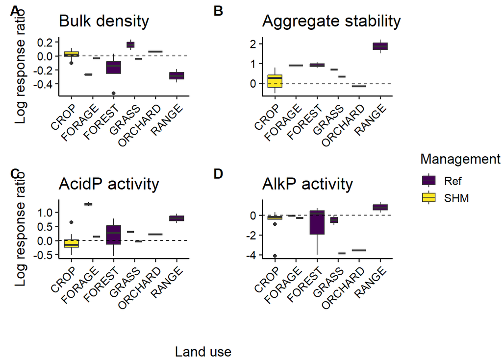

Takeaways:

- Land use is a significant moderator variable for bulk density, aggregate stability, and phosphatase activity (both acid and alkaline)
- Significant variability in all indicators between land uses, doesn’t seem to be a clear pattern though

### Tillage as a moderator variable

Calculate random-effects model with tillage as a moderator variable, generate table of results, and generate table of indicators for which tillage is a significant moderator variable:

| indicator | term | estimate | std.error | statistic | p.value | tau2 | i2 | h2 | r2 | q_stat | q_pval | q_mod | q_mod_pval | q_sig | q_mod_sig |
| --- | --- | --- | --- | --- | --- | --- | --- | --- | --- | --- | --- | --- | --- | --- | --- |
| bulk_density | factor(till)No-till | 0.128 | 0.176 | 0.72 | 0.469 | 0.026 | 90.42 | 10.44 | 9.50 | 215.9 | 0 | 4.0 | 0.14 | significant | not significant |
| bulk_density | factor(till)Perennial | -0.023 | 0.175 | -0.13 | 0.897 | 0.026 | 90.42 | 10.44 | 9.50 | 215.9 | 0 | 4.0 | 0.14 | significant | not significant |
| kssl_wsa | factor(till)No-till | -0.733 | 0.649 | -1.13 | 0.259 | 0.308 | 86.71 | 7.52 | 32.88 | 98.5 | 0 | 7.5 | 0.02 | significant | significant |
| kssl_wsa | factor(till)Perennial | 0.212 | 0.625 | 0.34 | 0.734 | 0.308 | 86.71 | 7.52 | 32.88 | 98.5 | 0 | 7.5 | 0.02 | significant | significant |
| yoder_agg_stab_mwd | factor(till)No-till | -0.777 | 0.739 | -1.05 | 0.293 | 0.433 | 97.57 | 41.07 | 15.40 | 279.8 | 0 | 4.7 | 0.09 | significant | not significant |
| yoder_agg_stab_mwd | factor(till)Perennial | -0.142 | 0.739 | -0.19 | 0.847 | 0.433 | 97.57 | 41.07 | 15.40 | 279.8 | 0 | 4.7 | 0.09 | significant | not significant |
| soc_pct | factor(till)No-till | -0.012 | 0.388 | -0.03 | 0.976 | 0.125 | 95.22 | 20.91 | 0.96 | 189.3 | 0 | 2.3 | 0.31 | significant | not significant |
| soc_pct | factor(till)Perennial | 0.255 | 0.386 | 0.66 | 0.508 | 0.125 | 95.22 | 20.91 | 0.96 | 189.3 | 0 | 2.3 | 0.31 | significant | not significant |
| ace | factor(till)No-till | -0.143 | 0.407 | -0.35 | 0.725 | 0.140 | 92.83 | 13.95 | 11.14 | 131.0 | 0 | 3.2 | 0.20 | significant | not significant |
| ace | factor(till)Perennial | 0.204 | 0.402 | 0.51 | 0.613 | 0.140 | 92.83 | 13.95 | 11.14 | 131.0 | 0 | 3.2 | 0.20 | significant | not significant |
| pox_c | factor(till)No-till | 0.065 | 0.406 | 0.16 | 0.873 | 0.143 | 100.00 | 33,739.27 | 0.00 | 690.5 | 0 | 0.7 | 0.70 | significant | not significant |
| pox_c | factor(till)Perennial | 0.193 | 0.404 | 0.48 | 0.632 | 0.143 | 100.00 | 33,739.27 | 0.00 | 690.5 | 0 | 0.7 | 0.70 | significant | not significant |
| soil_respiration | factor(till)No-till | -0.959 | 0.492 | -1.95 | 0.051 | 0.185 | 92.47 | 13.28 | 12.31 | 236.4 | 0 | 4.3 | 0.12 | significant | not significant |
| soil_respiration | factor(till)Perennial | -0.684 | 0.482 | -1.42 | 0.156 | 0.185 | 92.47 | 13.28 | 12.31 | 236.4 | 0 | 4.3 | 0.12 | significant | not significant |
| bglucosidase | factor(till)No-till | -0.663 | 0.768 | -0.86 | 0.388 | 0.455 | 94.90 | 19.62 | 0.00 | 274.4 | 0 | 0.9 | 0.65 | significant | not significant |
| bglucosidase | factor(till)Perennial | -0.511 | 0.764 | -0.67 | 0.504 | 0.455 | 94.90 | 19.62 | 0.00 | 274.4 | 0 | 0.9 | 0.65 | significant | not significant |
| bglucosaminidase | factor(till)No-till | -0.747 | 0.683 | -1.09 | 0.274 | 0.389 | 95.35 | 21.50 | 7.04 | 271.7 | 0 | 3.4 | 0.18 | significant | not significant |
| bglucosaminidase | factor(till)Perennial | -0.266 | 0.682 | -0.39 | 0.697 | 0.389 | 95.35 | 21.50 | 7.04 | 271.7 | 0 | 3.4 | 0.18 | significant | not significant |
| acid_phosphatase | factor(till)No-till | 0.038 | 0.539 | 0.07 | 0.944 | 0.191 | 85.87 | 7.08 | 28.97 | 111.8 | 0 | 7.6 | 0.02 | significant | significant |
| acid_phosphatase | factor(till)Perennial | 0.666 | 0.536 | 1.24 | 0.214 | 0.191 | 85.87 | 7.08 | 28.97 | 111.8 | 0 | 7.6 | 0.02 | significant | significant |
| alkaline_phosphatase | factor(till)No-till | 3.777 | 1.235 | 3.06 | 0.002 | 0.391 | 92.73 | 13.75 | 54.70 | 102.1 | 0 | 10.5 | 0.01 | significant | significant |
| alkaline_phosphatase | factor(till)Perennial | 3.995 | 1.238 | 3.23 | 0.001 | 0.391 | 92.73 | 13.75 | 54.70 | 102.1 | 0 | 10.5 | 0.01 | significant | significant |
| arylsulfatase | factor(till)No-till | 0.682 | 0.882 | 0.77 | 0.440 | 0.369 | 90.39 | 10.41 | 14.59 | 164.4 | 0 | 4.0 | 0.14 | significant | not significant |
| arylsulfatase | factor(till)Perennial | 1.187 | 0.880 | 1.35 | 0.178 | 0.369 | 90.39 | 10.41 | 14.59 | 164.4 | 0 | 4.0 | 0.14 | significant | not significant |

| indicator | term | estimate | std.error | statistic | p.value | tau2 | i2 | h2 | r2 | q_stat | q_pval | q_mod | q_mod_pval | q_sig | q_mod_sig |
| --- | --- | --- | --- | --- | --- | --- | --- | --- | --- | --- | --- | --- | --- | --- | --- |
| kssl_wsa | factor(till)No-till | -0.733 | 0.649 | -1.13 | 0.259 | 0.308 | 86.71 | 7.52 | 32.88 | 98.5 | 0 | 7.5 | 0.02 | significant | significant |
| kssl_wsa | factor(till)Perennial | 0.212 | 0.625 | 0.34 | 0.734 | 0.308 | 86.71 | 7.52 | 32.88 | 98.5 | 0 | 7.5 | 0.02 | significant | significant |
| acid_phosphatase | factor(till)No-till | 0.038 | 0.539 | 0.07 | 0.944 | 0.191 | 85.87 | 7.08 | 28.97 | 111.8 | 0 | 7.6 | 0.02 | significant | significant |
| acid_phosphatase | factor(till)Perennial | 0.666 | 0.536 | 1.24 | 0.214 | 0.191 | 85.87 | 7.08 | 28.97 | 111.8 | 0 | 7.6 | 0.02 | significant | significant |
| alkaline_phosphatase | factor(till)No-till | 3.777 | 1.235 | 3.06 | 0.002 | 0.391 | 92.73 | 13.75 | 54.70 | 102.1 | 0 | 10.5 | 0.01 | significant | significant |
| alkaline_phosphatase | factor(till)Perennial | 3.995 | 1.238 | 3.23 | 0.001 | 0.391 | 92.73 | 13.75 | 54.70 | 102.1 | 0 | 10.5 | 0.01 | significant | significant |

Plot relationship between tillage and indicator variables for which it is a significant predictor:

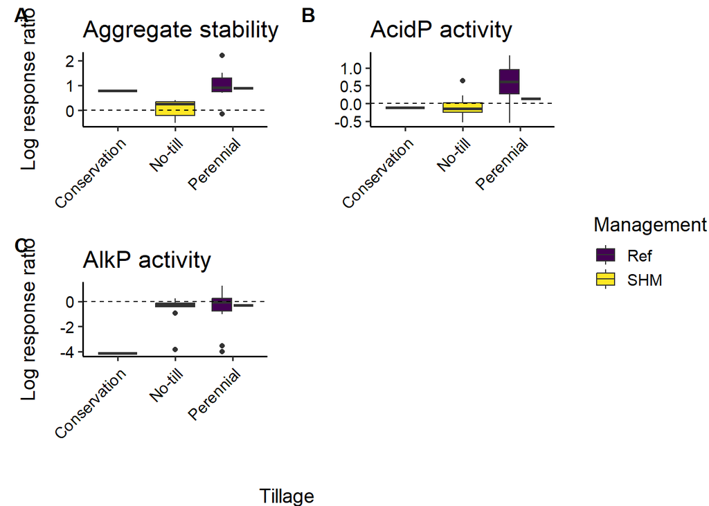

Takeaways:

- Tillage is a significant moderator variable for aggregate stability (which makes sense to me) and phosphatase activity (acid and alkaline, which makes less sense to me)
- Effect size of aggregate stability is smaller for no-till vs. conservation tillage or perennial systems - maybe just reflecting a Ref vs SHM difference?

### Clay content as a moderator variable

| indicator | estimate | std.error | statistic | p.value | tau2 | i2 | h2 | r2 | q_stat | q_pval | q_mod | q_mod_pval | q_sig | q_mod_sig |
| --- | --- | --- | --- | --- | --- | --- | --- | --- | --- | --- | --- | --- | --- | --- |
| bulk_density | -0.010 | 0.004 | -2.35 | 0.019 | 0.017 | 80.77 | 5.20 | 30.01 | 93.8 | 0.000 | 5.5 | 0.02 | significant | significant |
| kssl_wsa | 0.034 | 0.040 | 0.86 | 0.391 | 0.666 | 93.52 | 15.43 | 0.00 | 115.4 | 0.000 | 0.7 | 0.39 | significant | not significant |
| yoder_agg_stab_mwd | 0.028 | 0.022 | 1.26 | 0.206 | 0.542 | 98.35 | 60.62 | 6.48 | 203.2 | 0.000 | 1.6 | 0.21 | significant | not significant |
| soc_pct | -0.026 | 0.017 | -1.54 | 0.123 | 0.145 | 95.10 | 20.41 | 9.60 | 270.1 | 0.000 | 2.4 | 0.12 | significant | not significant |
| ace | -0.020 | 0.017 | -1.15 | 0.248 | 0.197 | 94.12 | 17.00 | 0.00 | 241.7 | 0.000 | 1.3 | 0.25 | significant | not significant |
| pox_c | -0.008 | 0.011 | -0.78 | 0.436 | 0.174 | 99.69 | 323.53 | 0.00 | 542.0 | 0.000 | 0.6 | 0.44 | significant | not significant |
| soil_respiration | 0.024 | 0.014 | 1.72 | 0.086 | 0.099 | 86.40 | 7.35 | 22.50 | 93.4 | 0.000 | 2.9 | 0.09 | significant | not significant |
| bglucosidase | 0.003 | 0.018 | 0.14 | 0.888 | 0.474 | 96.56 | 29.07 | 0.00 | 292.6 | 0.000 | 0.0 | 0.89 | significant | not significant |
| bglucosaminidase | -0.007 | 0.020 | -0.33 | 0.745 | 0.516 | 96.74 | 30.72 | 0.00 | 339.2 | 0.000 | 0.1 | 0.74 | significant | not significant |
| acid_phosphatase | 0.001 | 0.022 | 0.02 | 0.980 | 0.333 | 94.07 | 16.87 | 0.00 | 140.4 | 0.000 | 0.0 | 0.98 | significant | not significant |
| alkaline_phosphatase | 0.016 | 0.008 | 2.03 | 0.042 | 0.035 | 58.08 | 2.39 | 31.20 | 39.4 | 0.001 | 4.1 | 0.04 | significant | significant |
| arylsulfatase | -0.009 | 0.020 | -0.46 | 0.644 | 0.522 | 95.25 | 21.04 | 0.00 | 396.0 | 0.000 | 0.2 | 0.64 | significant | not significant |

# Recommendations for incorporating soil health information into soil survey

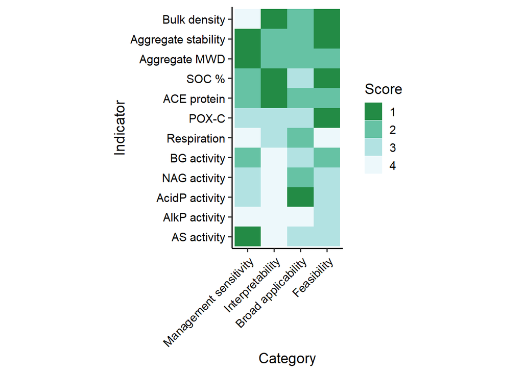